### Part I

#### Solution

Friday, November 14, 2014

**2.** In a study conducted by the Department of Human Nutrition and Foods at the Virginia Polytechnic Institute and State University the following data on the comparison of sorbic acid residuals in parts per million in ham immediately after dipping in a sorbate solution and after 60 days of storage were recorded:

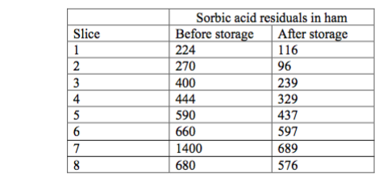

1. Using a parametric method, is there sufficient evidence, at the $0.05$ level of significance, to say that the 60 days of storage influences sorbic acid residual concentrations?
   **Solution**
   This is a paired *t* test.
   $H_0: \mu_{before} = \mu_{after}$ or, equivalently $\mu_{Diff} = 0$
   $H_a: \mu_{before} \neq \mu_{after}$ or, equivalently $\mu_{Diff} \neq 0$
   T.S.:
   $$t^*= \frac{\overline{D} - D_0}{s_{Diff}/\sqrt{n_{pairs}}}$$
   where $t^* \sim t_{(n-1)}$ and, in this case, $D_0=0$.
   $$\begin{matrix}
   \text{Slice} & \text{Difference} \\
   1 & 108 \\
   2 & 174 \\
   3 & 161 \\
   4 & 115 \\
   5 & 153 \\
   6 & 63 \\
   7 & 711 \\
   8 & 104
   \end{matrix} \\
   \overline{D} = \frac{1}{8}(108 + 174 + 161 + 115 + 153 + 63 + 711 + 104) = 198.625 \\
   s^2_{Diff} = \frac{1}{n-1} \sum_{i=1}^8 (D_i - \overline{D})^2 = 44169.41$$
   $s_{Diff} = 210.1652$
   $$t^* = \frac{198.625 - 0}{210.1652/\sqrt{8}} = 2.673118$$
   where $df=8-1=7$.
   Rejection Region: $t_{0.975,\ 7}=2.365$
   $t^* > t_{0.975,\ 7}$
   We conclude with 95% confidence that there is sufficient evidence that the length of storage influences sorbic acid residual concentrations.
2. Repeat (a) but use the $0.01$ level of significance. Does your answer change? Explain why the answer may depend on the level of significance.  
   **Solution**  
   Rejection Region: $t_{0.975,\ 7}=3.499$  
   At the 0.01 level of significance, there is not sufficient evidence that the length of storage influences sorbic acid residual concentrations.
3. What are the assumptions of your test in (a)? Verify the distribution assumption by stem-and-leaf plots or histograms.  
   **Solution**  
   “One assumption is that these 8 slices is a random sample of all ham slices. The other assumption of the paired *t* test is the distribution of differences $(before - after)$ is normal. From the histogram we can see the data distribution is far different from bell shape, so the normality assumption is violated.”

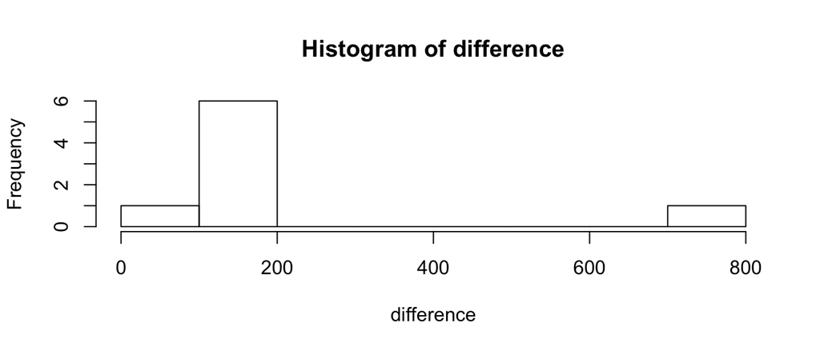

4. If an assumption in (c) is violated, what is an alternative non-parametric test? List hypotheses of this non-parametric test and its assumption.  
   **Solution**  
   “We can use the Wilcoxon signed-rank test. This test assumes a symmetric distribution of differences and it is testing equal medians: (M represents median)”  
   $H_0: M_{diff}=0$  
   $H_a: M_{diff} \neq 0$